# L12

# Probabilities

## Uncertainty

- Observed variables (evidence) ≙ agent knows certain things about the state of the world (eg: sensor readings or symptoms)
- Unobserved (hidden) variables ≙ Agent needs to reason about other aspects (eg: where an object is or what disease is present)
- Model ≙ agent knows something about how the known variables relate to the unknown variables

## Random Variables

- RV ≙ some aspect of the world about which we (may) have certainty
- Commonly indicated with capital letters
- Have explicit domains ($R\in\{\mathrm{true},\mathrm{false}\}\;\hat{=}\;{\{+r,-r\}}$)
- Associate probability with each value in the domain
  - Can use a probability table for showing all of them
  - Single probability of a lower-case value is a single number
  - eg: $\mathbb{P}[W=\text{rain}]=0.{1\iff}\mathbb{P}[\text{rain}]=0.1$
  - Each probability sum to 1 and be positive
- Size of distribution of $n$ variables with domain sizes $d$ is $d^{n}$
  - For every $n$ variables, there are $d$ possible choices
- Probabilistic model is just a joint distribution over a set of RVs

## Events

### Conditional Probabilities

- A simple relation between joint and conditional probabilities
- $\mathbb{P}(a|b)=\frac{\mathbb{P}(a,b)}{\mathbb{P}(b)}$
- ‘Proportion of $b$ where $a$ holds’
- Normalization trick:
  - Take the entries in a table that you are stipulating and normalize the values to get the new probabilities

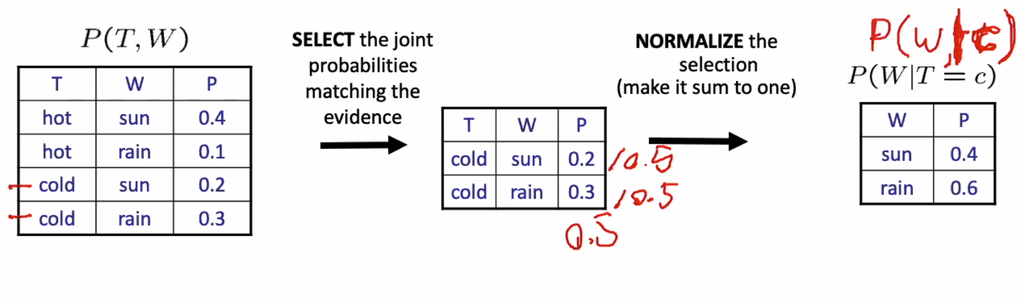

### Probabilistic Inference

- Compute a desired probability from other known probabilities (eg conditional from joint)
- Observing new evidence causes ‘beliefs’ to change
- Given $\{X_{1},X_{2},{\dots},X_{n}\}$, separate into
  - Evidence variables: $\{E_{1},E_{2},{\dots},E_{n}\}$ representing known state
  - Query variables $Q$ representing what you care about
  - Hidden variables: $\{H_{1},H_{2},{\dots},H_{r}\}$ representing unknown variables that we don’t know or care about
- Want $\mathbb{P}(Q|e_{1},{\dots},e_{k})$

#### Inference by Enumeration

- Steps:
  1. Select the entries consistent with the evidence
  2. Sum out $H$ to get joint of query and evidence
  3. Normalize (multiply probabilities by $\frac{1}{Z}$)
- Worst case time complexity in $O(d^{n})$
- Space complexity in $O(d^{n})$ to store the joint distribution

## Rules

- Product rule: $\mathbb{P}(y)\mathbb{P}(x|y)=\mathbb{P}(x,y)$
  - eg: $\mathbb{P}(x_{1},x_{2},x_{3})=\mathbb{P}(x_{1})\mathbb{P}(x_{2}|x_{1})\mathbb{P}(x_{3}|x_{1},x_{2})$
  - Generally, $\mathbb{P}(x_{1},x_{2},{\dots},x_{n})=\prod_{i}\mathbb{P}(x_{i}|x_{1},x_{2},{\dots},x_{i-1})$
- Bayes rule: $\mathbb{P}(x,y)=\mathbb{P}(x|y)\mathbb{P}(y)=\mathbb{P}(y|x)\mathbb{P}(x)$
  - Also $\mathbb{P}(x|y)=\frac{\mathbb{P}(y|x)}{\mathbb{P}(y)}\mathbb{P}(x)$
  - Lets us build one conditional from its reverse
  - Often one conditional is tricky, but the other one is simple